# Wide and long format

Thomas Nauss

19 Oktober 2017

The following is a short note on converting wide to long format required e.g. for some lattice or ggplot visualizations. The following examples are based on the readily known data set showing the percentage fraction of settlement, recreational, agricultural, and forest areas for each rural district in Germany. The data has been provided through the [Regional Database Germany](https://www.regionalstatistik.de/genesis/online/).

```r
library(latticeExtra)
```

We already know that a boxplot is probably the most fundamental way to perform a visual data exploration. Producing it is straight forward in generic plotting: Producing a boxplot is staright forward (the x-axis lables are just the column names):

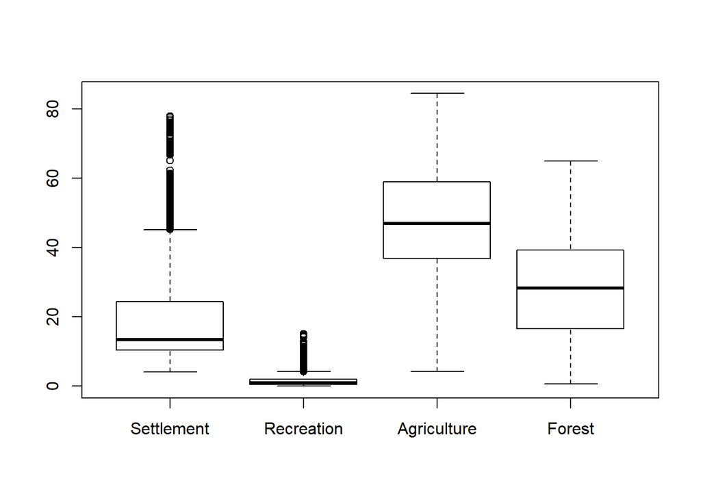

```r
boxplot(lu[, c("Settlement", "Recreation", "Agriculture", "Forest")])
```

Producing a boxplot in lattice is not so staright forward as in generic plotting if you whish to have multiple variables shown in one plot. Before one can plot it, one has to transform the data into “long” format. In the case of our dataset, this implies to identify the ID variables (i.e. the ones who define the place and time of the measurement). After this is done, the long-format will duplicate them as often as it is required to fit in all values of the other columns (i.e. setellment, recreation, agriculture and forest) and add the respective values in a seperate column.

That’s what the data looks like in it’s original format:

```r
head(lu)
```

```
##   Year   ID                                          Place Settlement
## 1 1996   DG                                    Deutschland       11.8
## 2 1996    1                             Schleswig-Holstein       10.8
## 3 1996 1001                    Flensburg, Kreisfreie Stadt       47.3
## 4 1996 1002       Kiel, Landeshauptstadt, Kreisfreie Stadt       52.1
## 5 1996 1003           Lbeck, Hansestadt, Kreisfreie Stadt       30.2
## 6 1996 1004                   Neumnster, Kreisfreie Stadt       46.4
##   Recreation Agriculture Forest
## 1        0.7        54.1   29.4
## 2        0.7        73.0    9.3
## 3        5.1        25.1    6.0
## 4        1.3        34.7    3.3
## 5        2.9        39.7   12.9
## 6        4.9        46.9    3.4
```

And this is the data after conversion to long format using the `reshape2::melt` function:

```r
lul <- reshape2::melt(lu, id.vars = c("Year", "ID", "Place"))
head(lul)
```

```
##   Year   ID                                          Place   variable
## 1 1996   DG                                    Deutschland Settlement
## 2 1996    1                             Schleswig-Holstein Settlement
## 3 1996 1001                    Flensburg, Kreisfreie Stadt Settlement
## 4 1996 1002       Kiel, Landeshauptstadt, Kreisfreie Stadt Settlement
## 5 1996 1003           Lbeck, Hansestadt, Kreisfreie Stadt Settlement
## 6 1996 1004                   Neumnster, Kreisfreie Stadt Settlement
##   value
## 1  11.8
## 2  10.8
## 3  47.3
## 4  52.1
## 5  30.2
## 6  46.4
```

Afterwards, the data can also be used e.g. for producing boxplots in lattice:

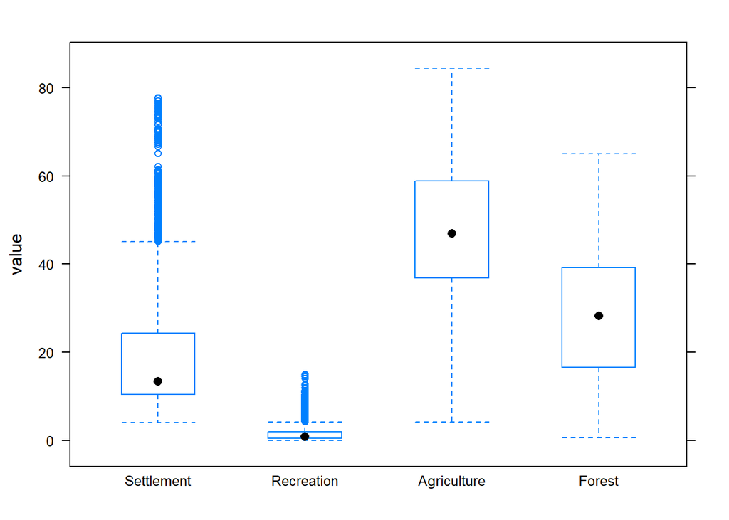

```r
bwplot(value ~ variable, data = lul)
```